# Enquête logiciels SU - Septembre 2015

FEDORU

07/09/2015

Objectif: lesRPU sont produits par des ES disposant d’une autorisation de SU. Les informations sont issues des données d’un patient, recueillis par du personnel administratif, soignant et médical sur un logiciel mis à disposition par le service informatique de l’établissement. Le logiciel est fourni par un éditeur ou plus rarement développé localement et administré par le service informatique de l’établissement hospitalier (SIH). La qualité et l’exhaustivité des RPU dépend d’une chaine d’intervenant. Un RPU est considéré comme crée s’il comporte la date et heure d’entrée, le code postal, la commune et la date de naissance d’un consultant (?).L’exhaustivité est la diffférence entre le nombre de RPU produits pendant une période et le nombre de primo passage aux urgences sur la même période. Il n’y a pas de référentiel absolu pour mesurer le nombre de primo passages. Selon le cas il peut s’agir du nombre de RPU eux-mêmes, du chiffre de la SAE, d’une mesure à partir du PMSI. La qualité des RPU se mesure par l’écart entre la valeur attendue d’un item et la réponse fournie. La réponse fournie peut être manquante ou non conforme à un référentiel de valeur. Le référentiel s’appuie sur la cahier des charges de l’INVS, sur des référentiels issus de sociétés savantes (SFMU) ou sur des consenssus d’expert (FEDORU).

# 1 Historique

- 7/9/2015 Reprise de l’exploitation des logiciels des SU
  - fichier source: DATA/FEDORU - ENQUETE LOGICIEL 2015 - V2 (12 06 15) (3)
  - création d’un dossier spécifique **Septembre2015** contenent un sous dossier **data** pour y stocker les résultats régionaux sous forme de fichier .csv.
- 17/9/2015 récup données ORUMIP (Olivier Azema)
- 18/9/2015 données Bourgogne mises à jour
- 30/9/2015 intégration des données de la Franche-comté
- 13/10/2015 intégration de la Lorraine

## 1.1 Récupération des fichiers csv

```
[1] "alsace.csv"
[1] "alsace.csv~"
[1] "aquitaine.csv"
[1] "bourgogne.csv"
[1] "bretagne.csv"
[1] "champagne.csv"
[1] "franche_comte.csv"
[1] "limousin.csv"
[1] "lorraine2.csv"
[1] "midipy.csv"
[1] "ORUMIP.csv"
[1] "paca.csv"
[1] "rhone.csv"
```

```
[1] "/Users/jcb/Documents/FEDORU/InformatisationSU/Septembre2015"
```

# 2 Données générales

Périmètre du questionnaire:

- période: 1er janvier 2015 au 31 mars 2015 (1er trimestre)
- concerne toutes les structures volontaires membres de la FEDORU. Coordination régionale assurée par les ORU
- questions

## 2.1 Résultats

- Nombre de régions participantes: 11:

```
 [1] "ALSACE"             "AQUITAINE"          "BOURGOGNE"          "BRETAGNE"
 [5] "CHAMPAGNE ARDENNES" "FRANCHE COMTE"      "LIMOUSIN"           "LORRAINE"
 [9] "MIDI PYRENEES"      "PACA"               "RHONE ALPES"
```

# 3 Cartographie

Cartographie des régions participantes et des logiciels.

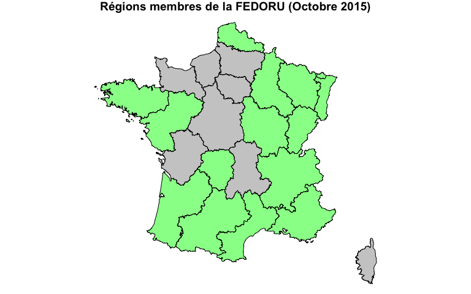

Régions participantes à l’étude

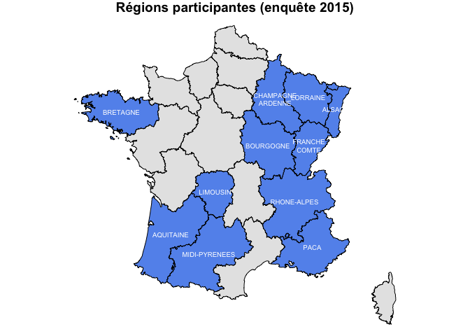

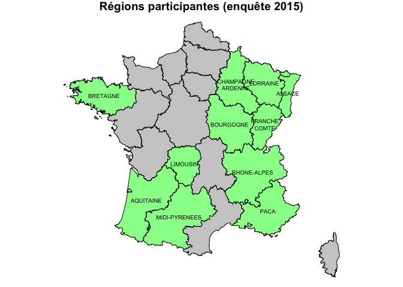

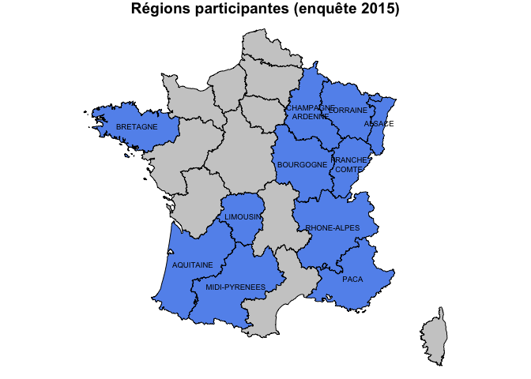

# 4 Editeurs

- Dans la majorité des cas (79.03), les répondants ne connaissent pas leur éditeur.
- Il en est de même pour la version: 63.44 % des cas, la version n’est pas précisée.

# 5 Logiciels 2015

## 5.1 Logiciels par ordre décroissant

```
                  DMU           RESURGENCES            TU-ORUPACA                URQUAL
                   50                    47                    47                    40
             CROSSWAY                DXCARE              ATALANTE             MEDIBOARD
                   20                    18                    13                     9
                SIDSU                 ORUV2      SILLAGE URGENCES              DOPASOIN
                    9                     8                     8                     6
             FIRSTNET                 ORBIS              CLINICOM             POLYMEDIS
                    6                     6                     5                     5
              ANTARES              CORTEXTE DEVELOPPEMENT INTERNE                   DPU
                    4                     4                     4                     4
       MÉDICAL OBJECT            RPUEXPRESS         DOPA URGENCES               EXAGONE
                    4                     4                     3                     3
         EXPERT SANTE              EXPERTIZ                SIGEMS                DIAMMS
                    3                     3                     3                     2
              DX CARE                  EMED               H+ACUTE       HOPITAL MANAGER
                    2                     2                     2                     2
               OSIRIS                 OSOFT               SANOCOM             SHAREGATE
                    2                     2                     2                     2
          SILLAGE DMU               AXIGATE                CLIMCO          CORA URGENCE
                    2                     1                     1                     1
               CORPUS              E SHERPA              EQUAFILE                M-PLUS
                    1                     1                     1                     1
             MEDIBASE              MEDINTUX                 MEDIS              MEDIWERE
                    1                     1                     1                     1
               NAFAMA                 QCARE               SPEC 4D            TRACK CARE
                    1                     1                     1                     1
               URGEST
                    1
```

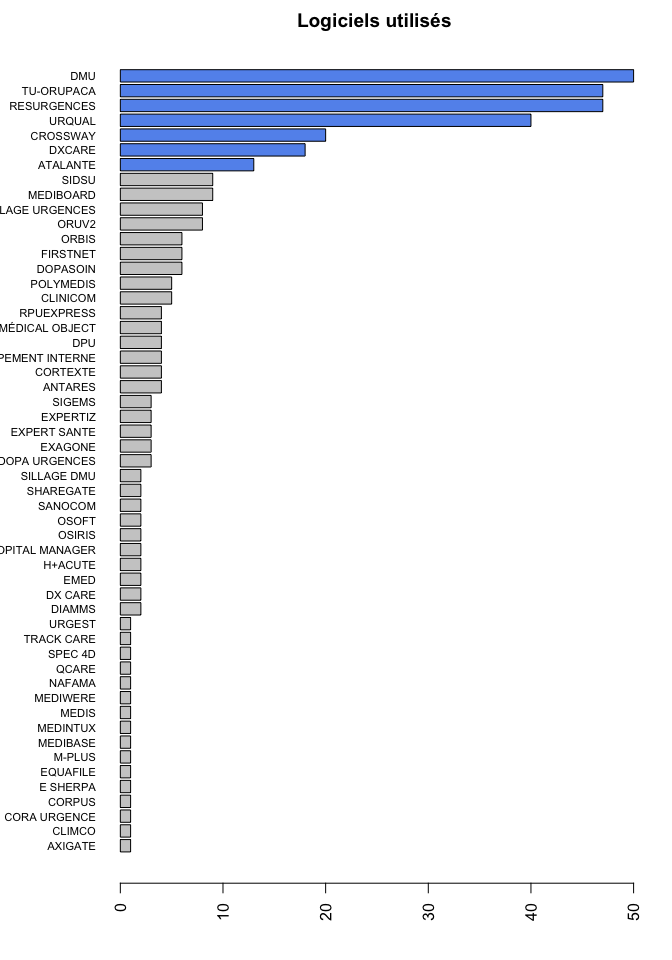

Top Ten

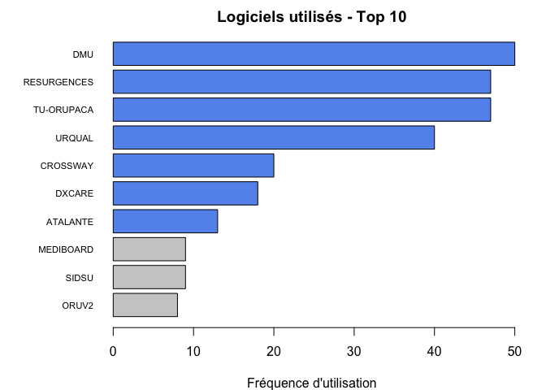

```r
par(mar=c(4,7,2,2))
t <- sort(table(d$Logiciel_2015), decreasing = TRUE)
t10 <- t[10:1]
barplot(t10, horiz = TRUE, las = 1, cex.names = 0.7, main = "Logiciels utilisés - Top 10", col = ifelse(t10 > 9, "cornflowerblue", "gray80"), xlab = "Fréquence d'utilisation")
```

## 5.2 Logiciels par région

```
                        ALSACE AQUITAINE BOURGOGNE BRETAGNE CHAMPAGNE ARDENNES
  ANTARES                    4         0         0        0                  0
  ATALANTE                  11         0         2        0                  0
  AXIGATE                    0         1         0        0                  0
  CLIMCO                     0         0         0        0                  0
  CLINICOM                   2         0         0        0                  0
  CORA URGENCE               0         0         0        0                  0
  CORPUS                     0         0         0        0                  0
  CORTEXTE                   0         0         0        0                  0
  CROSSWAY                   0         3         3        0                  0
  DEVELOPPEMENT INTERNE      0         0         0        0                  0
  DIAMMS                     0         0         0        0                  0
  DMU                        2         0         7        0                  3
  DOPA URGENCES              0         1         0        0                  2
  DOPASOIN                   0         0         0        0                  0
  DPU                        0         0         0        0                  0
  DX CARE                    2         0         0        0                  0
  DXCARE                     4         6         1        0                  1
  E SHERPA                   0         0         0        0                  0
  EMED                       0         0         0        0                  0
  EQUAFILE                   0         0         0        0                  0
  EXAGONE                    0         0         1        0                  0
  EXPERT SANTE               0         0         0        0                  0
  EXPERTIZ                   0         0         0        0                  0
  FIRSTNET                   0         0         0        0                  0
  H+ACUTE                    0         0         0        0                  0
  HOPITAL MANAGER            0         0         2        0                  0
  M-PLUS                     0         1         0        0                  0
  MEDIBASE                   0         1         0        0                  0
  MEDIBOARD                  0         0         0        1                  0
  MÉDICAL OBJECT             0         0         0        0                  0
  MEDINTUX                   0         0         0        0                  0
  MEDIS                      0         0         0        1                  0
  MEDIWERE                   0         0         0        0                  0
  NAFAMA                     0         0         0        0                  1
  ORBIS                      2         0         0        1                  0
  ORUV2                      0         0         0        0                  0
  OSIRIS                     0         0         0        0                  0
  OSOFT                      0         0         0        1                  0
  POLYMEDIS                  0         0         0        0                  5
```

[output cut: 54 more lines]

```
  POLYMEDIS                         0        0        0             0    0           0
  QCARE                             0        0        0             0    1           0
  RESURGENCES                       5        6       17             0    2           3
  RPUEXPRESS                        0        0        0             4    0           0
  SANOCOM                           0        0        0             0    0           0
  SHAREGATE                         0        0        0             0    0           0
  SIDSU                             0        0        0             0    0           0
  SIGEMS                            0        0        0             0    0           1
  SILLAGE DMU                       0        0        0             0    0           0
  SILLAGE URGENCES                  0        0        0             0    0           0
  SPEC 4D                           0        1        0             0    0           0
  TRACK CARE                        0        0        0             0    0           0
  TU-ORUPACA                        0        0        0             4   42           0
  URGEST                            0        0        0             0    0           1
  URQUAL                            0        2        0            10    2           6
```

Nombre de logiciels différents par région

```
            ALSACE          AQUITAINE          BOURGOGNE           BRETAGNE
                 8                 14                  9                  8
CHAMPAGNE ARDENNES      FRANCHE COMTE           LIMOUSIN           LORRAINE
                 7                  4                  3                  5
     MIDI PYRENEES               PACA        RHONE ALPES
                17                  6                 18
```

Nombre de logiciels différents par rapport au nombre de SU de la région

```
              PACA           LORRAINE      MIDI PYRENEES        RHONE ALPES
              0.12               0.22               0.23               0.26
          BRETAGNE             ALSACE      FRANCHE COMTE           LIMOUSIN
              0.27               0.28               0.31               0.33
         BOURGOGNE          AQUITAINE CHAMPAGNE ARDENNES
              0.39               0.40               0.44
```

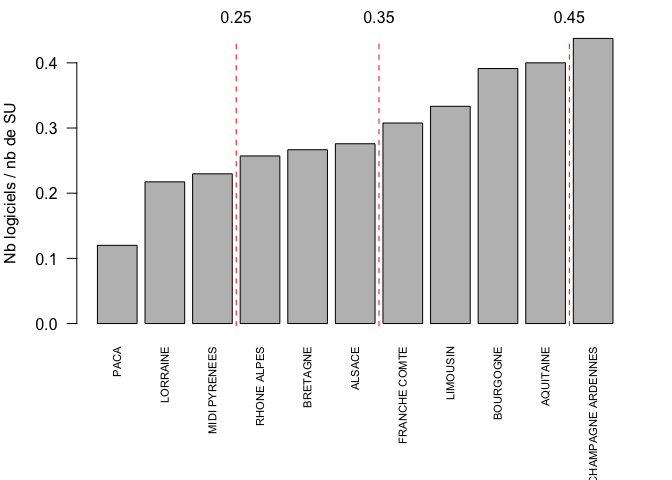

## 5.3 Cartographie des logiciels

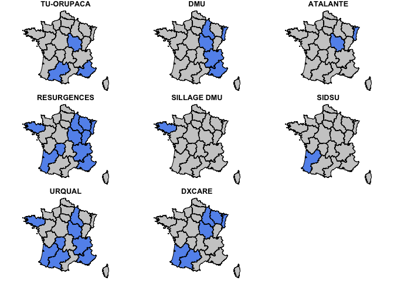

## 5.4 Un logiciel est présent dans combien de régions ?

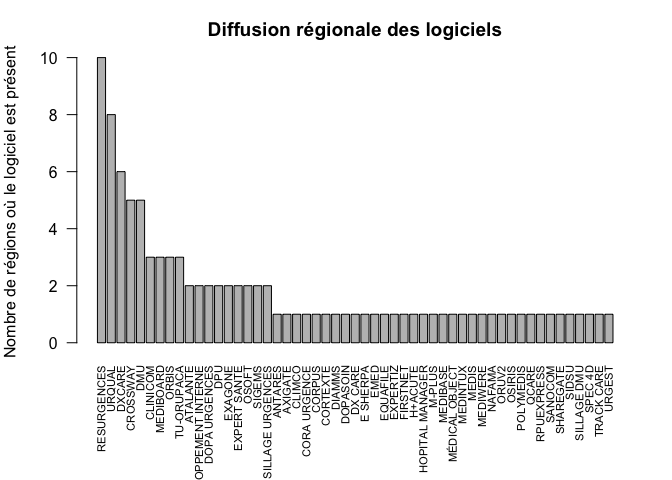

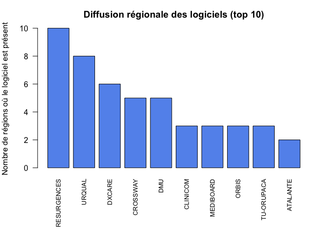

# 6 Analyse des RPU

Nombre de RPU produits: 2323895

## 6.1 Nombre de RPU par logiciel

```
                      Nb de RPU
URQUAL                   377231
TU-ORUPACA               367714
RESURGENCES              347104
DMU                      299522
DXCARE                   135660
CROSSWAY                 106311
ATALANTE                  59400
DPU                       45087
SIDSU                     44401
MEDIBOARD                 42388
FIRSTNET                  33773
SILLAGE URGENCES          32519
CLINICOM                  27188
MÉDICAL OBJECT            25154
CORTEXTE                  24738
ORUV2                     21430
EXPERT SANTE              20440
POLYMEDIS                 20363
DOPASOIN                  18658
ANTARES                   17948
DEVELOPPEMENT INTERNE     17490
EXPERTIZ                  15215
DX CARE                   14920
EXAGONE                   14004
ORBIS                     13694
SILLAGE DMU               11801
TRACK CARE                11345
DOPA URGENCES             10420
RPUEXPRESS                10410
M-PLUS                     9970
H+ACUTE                    9762
SHAREGATE                  8639
CLIMCO                     8565
SIGEMS                     7231
SANOCOM                    7150
OSOFT                      7050
SPEC 4D                    7015
MEDIS                      6974
CORA URGENCE               6618
URGEST                     6321
MEDINTUX                   6224
MEDIWERE                   5676
NAFAMA                     5156
QCARE                      5131
AXIGATE                    4282
E SHERPA                   4090
OSIRIS                     4038
DIAMMS                     3666
CORPUS                     3601
EMED                       3246
MEDIBASE                   2913
HOPITAL MANAGER            2644
EQUAFILE                   1605
```

## 6.2 Nombre de jours manquants

### 6.2.1 nombre de jours

```r
n.jours <- as.numeric(difftime(as.Date("2015-03-31"), as.Date("2015-01-01")))

# nombre de jours logiciels
t2 <- summary(d$Logiciel_2015) * n.jours

# nombre total de jours-logiciels attendus
n.jour.logiciel = sum(t2)
n.jour.logiciel
```

```
[1] 33108
```

### 6.2.2 Par logiciel

```
                      Nb de jours manquants
DOPASOIN                             118.00
URQUAL                               117.00
EMED                                 100.00
TU-ORUPACA                            90.00
CROSSWAY                              63.03
ORBIS                                 55.00
SILLAGE URGENCES                      42.00
OSOFT                                 21.00
DMU                                   20.00
DEVELOPPEMENT INTERNE                 17.00
DPU                                    9.00
CLINICOM                               8.00
RESURGENCES                            5.56
MEDIBOARD                              4.00
HOPITAL MANAGER                        3.00
ANTARES                                2.00
ATALANTE                               2.00
E SHERPA                               2.00
EQUAFILE                               0.31
FIRSTNET                               0.04
AXIGATE                                0.00
CLIMCO                                 0.00
CORA URGENCE                           0.00
CORPUS                                 0.00
CORTEXTE                               0.00
DIAMMS                                 0.00
DOPA URGENCES                          0.00
DX CARE                                0.00
DXCARE                                 0.00
EXAGONE                                0.00
EXPERT SANTE                           0.00
EXPERTIZ                               0.00
H+ACUTE                                0.00
M-PLUS                                 0.00
MEDIBASE                               0.00
MÉDICAL OBJECT                         0.00
MEDINTUX                               0.00
MEDIS                                  0.00
MEDIWERE                               0.00
NAFAMA                                 0.00
ORUV2                                  0.00
OSIRIS                                 0.00
POLYMEDIS                              0.00
QCARE                                  0.00
RPUEXPRESS                             0.00
SANOCOM                                0.00
SHAREGATE                              0.00
SIDSU                                  0.00
SIGEMS                                 0.00
SILLAGE DMU                            0.00
SPEC 4D                                0.00
TRACK CARE                             0.00
URGEST                                 0.00
```

```
                        Min   Max moyenne médiane ecart.type Nb   Q25   Q75
ANTARES                0.00  1.00  0.5000    0.50      0.577  4  0.00  1.00
ATALANTE               0.00  1.00  0.1538    0.00      0.376 13  0.00  0.00
AXIGATE                0.00  0.00  0.0000    0.00         NA  1  0.00  0.00
CLIMCO                 0.00  0.00  0.0000    0.00         NA  1  0.00  0.00
CLINICOM               0.00  4.00  1.6000    0.00      2.191  5  0.00  4.00
CORA URGENCE           0.00  0.00  0.0000    0.00         NA  1  0.00  0.00
CORPUS                  Inf  -Inf     NaN      NA         NA  1    NA    NA
CORTEXTE               0.00  0.00  0.0000    0.00      0.000  4  0.00  0.00
CROSSWAY               0.00 63.00  3.5017    0.00     14.849 20  0.00  0.00
DEVELOPPEMENT INTERNE  0.00 17.00  4.2500    0.00      8.500  4  0.00  4.25
DIAMMS                 0.00  0.00  0.0000    0.00      0.000  2  0.00  0.00
DMU                    0.00 16.00  0.4167    0.00      2.314 50  0.00  0.00
DOPA URGENCES          0.00  0.00  0.0000    0.00      0.000  3  0.00  0.00
DOPASOIN               0.00 59.00 19.6667    0.00     30.467  6  0.00 44.25
DPU                    0.00  9.00  2.2500    0.00      4.500  4  0.00  2.25
DX CARE                0.00  0.00  0.0000    0.00      0.000  2  0.00  0.00
DXCARE                 0.00  0.00  0.0000    0.00      0.000 18  0.00  0.00
E SHERPA               2.00  2.00  2.0000    2.00         NA  1  2.00  2.00
EMED                  50.00 50.00 50.0000   50.00      0.000  2 50.00 50.00
EQUAFILE               0.31  0.31  0.3100    0.31         NA  1  0.31  0.31
EXAGONE                0.00  0.00  0.0000    0.00      0.000  3  0.00  0.00
EXPERT SANTE           0.00  0.00  0.0000    0.00      0.000  3  0.00  0.00
EXPERTIZ               0.00  0.00  0.0000    0.00      0.000  3  0.00  0.00
FIRSTNET               0.00  0.04  0.0067    0.00      0.016  6  0.00  0.00
H+ACUTE                 Inf  -Inf     NaN      NA         NA  2    NA    NA
HOPITAL MANAGER        0.00  3.00  1.5000    1.50      2.121  2  0.75  2.25
M-PLUS                 0.00  0.00  0.0000    0.00         NA  1  0.00  0.00
MEDIBASE               0.00  0.00  0.0000    0.00         NA  1  0.00  0.00
MEDIBOARD              0.00  1.00  0.4444    0.00      0.527  9  0.00  1.00
MÉDICAL OBJECT         0.00  0.00  0.0000    0.00      0.000  4  0.00  0.00
MEDINTUX               0.00  0.00  0.0000    0.00         NA  1  0.00  0.00
MEDIS                  0.00  0.00  0.0000    0.00         NA  1  0.00  0.00
MEDIWERE               0.00  0.00  0.0000    0.00         NA  1  0.00  0.00
NAFAMA                 0.00  0.00  0.0000    0.00         NA  1  0.00  0.00
ORBIS                  0.00 25.00 13.7500   15.00     13.150  6  3.75 25.00
ORUV2                  0.00  0.00  0.0000    0.00      0.000  8  0.00  0.00
OSIRIS                 0.00  0.00  0.0000    0.00      0.000  2  0.00  0.00
OSOFT                  0.00 21.00 10.5000   10.50     14.849  2  5.25 15.75
POLYMEDIS              0.00  0.00  0.0000    0.00      0.000  5  0.00  0.00
QCARE                  0.00  0.00  0.0000    0.00         NA  1  0.00  0.00
RESURGENCES            0.00  5.00  0.1853    0.00      0.911 47  0.00  0.00
RPUEXPRESS             0.00  0.00  0.0000    0.00      0.000  4  0.00  0.00
SANOCOM                0.00  0.00  0.0000    0.00      0.000  2  0.00  0.00
SHAREGATE              0.00  0.00  0.0000    0.00      0.000  2  0.00  0.00
SIDSU                  0.00  0.00  0.0000    0.00      0.000  9  0.00  0.00
SIGEMS                 0.00  0.00  0.0000    0.00      0.000  3  0.00  0.00
SILLAGE DMU            0.00  0.00  0.0000    0.00      0.000  2  0.00  0.00
SILLAGE URGENCES       0.00 42.00  5.2500    0.00     14.849  8  0.00  0.00
SPEC 4D                0.00  0.00  0.0000    0.00         NA  1  0.00  0.00
TRACK CARE             0.00  0.00  0.0000    0.00         NA  1  0.00  0.00
TU-ORUPACA             0.00 90.00  1.9149    0.00     13.128 47  0.00  0.00
URGEST                 0.00  0.00  0.0000    0.00         NA  1  0.00  0.00
URQUAL                 0.00 85.00  3.0000    0.00     13.792 40  0.00  0.50
```

```
[1] 679
```